# Análise Exploratória

Wagner Oliveira

28/04/2021

## Install packages

```r
#install.packages("tidyverse")
#install.packages("summarytools")
#install.packages("ggplot2")
#install.packages("quantmod")    # Framework Quantitativo para Mercado Financeiro
#install.packages("Quandl")     # Coletar Cotações do Índice Ibovespa
#install.packages("gridExtra") # Graficos acomplados
#install.packages("ggpubr")
#install.packages("GGally")
```

### Carregamentos dos pacotes

```r
library(tidyverse)
library(summarytools)
library(ggplot2)
library(quantmod)
library(gridExtra)
library(ggpubr)
library(GGally)
```

## Baixando a base do Yahoo Finance e Validando período da base

```r
getSymbols(c("^BVSP"),
           periodicity='monthly',
           from='2000-01-01',
           to='2021-04-15'
           )
```

```
## [1] "^BVSP"
```

### Descreva estatisticamente as base de dados

```r
descr(BVSP)
```

```
## Descriptive Statistics
##
##                     BVSP.Adjusted   BVSP.Close   BVSP.High    BVSP.Low   BVSP.Open     BVSP.Volume
## ----------------- --------------- ------------ ----------- ----------- ----------- ---------------
##              Mean        51281.95     51281.95    53692.42    48265.97    50874.00    150126896.88
##           Std.Dev        27148.70     27148.70    28178.37    25886.08    26865.51    451408563.01
##               Min         8623.00      8623.00    10477.00     8225.00     8642.00            0.00
##                Q1        26119.00     26119.00    26966.50    24208.00    25625.50            0.00
##            Median        53183.00     53183.00    55450.00    49927.00    53125.50     54056700.00
##                Q3        65607.50     65607.50    68090.00    62265.50    65403.00     81026250.00
##               Max       121053.00    121053.00   125324.00   114991.00   119024.00   2898315900.00
##               MAD        23745.32     23745.32    24113.01    23690.47    23657.11     61439166.39
##               IQR        39347.75     39347.75    41002.75    37934.25    39568.75     80982075.00
##                CV            0.53         0.53        0.52        0.54        0.53            3.01
##          Skewness            0.34         0.34        0.34        0.37        0.32            4.57
##       SE.Skewness            0.15         0.15        0.15        0.15        0.15            0.15
##          Kurtosis           -0.39        -0.39       -0.40       -0.36       -0.44           20.17
##           N.Valid          256.00       256.00      256.00      256.00      256.00          256.00
##         Pct.Valid          100.00       100.00      100.00      100.00      100.00          100.00
```

#### Crie um gráfico com a matriz de espalhamento (scatter matrix plot) para sua base de dados. Através de investigação visual, quais são as variáveis mais correlacionadas. Apresente o gráfico e justifique.

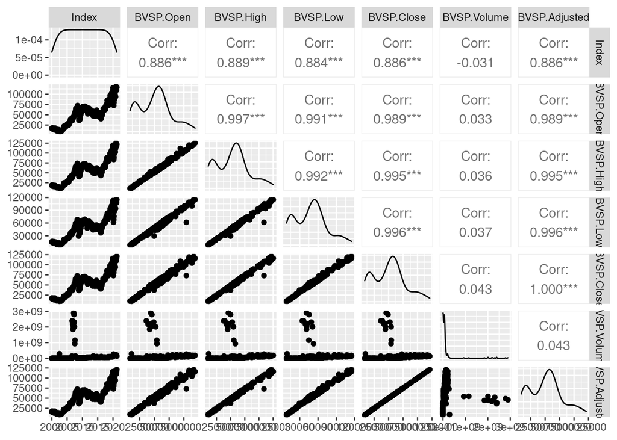

```r
ggpairs(BVSP)
```

#### As váriaveis Open, High, Low, Close e Adjuste. São totalmente correlacionadas positivamente, pois acompanham o crescimento do indice Bovespa.

### 5 -Sobre a normalidade das variáveis:

#### a. Descreva o que é uma distribuição normal;

##### D istribuição Normal é a mais importante distribuição contínua. Importante para diversas práticas, destaco o Teorema Central do Limite, para garantir a média de um conjunto de dados que converge para uma distribuição normal conforme o número de dados cresce.

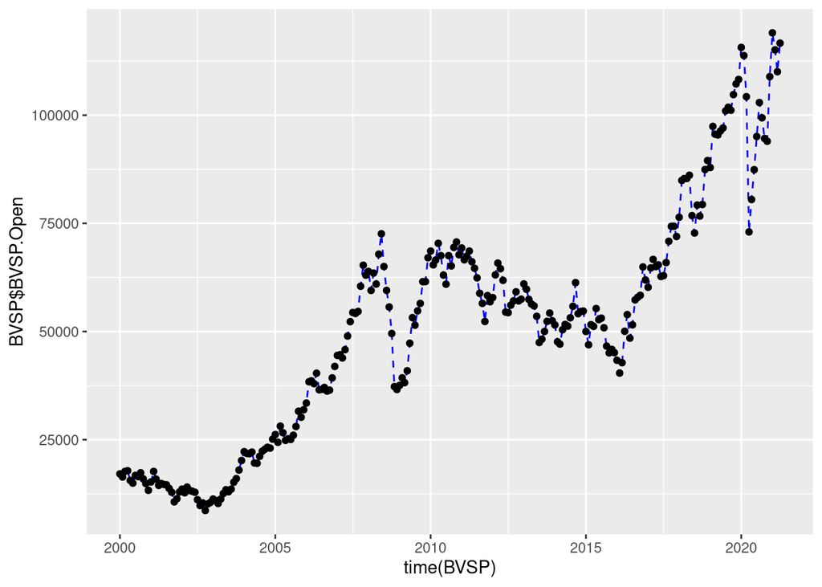

```r
# Variável Open
ggplot(BVSP, aes(time(BVSP), BVSP$BVSP.Open, group=1)) +
  geom_line(color="blue",linetype = "dashed")+
  geom_point()
```

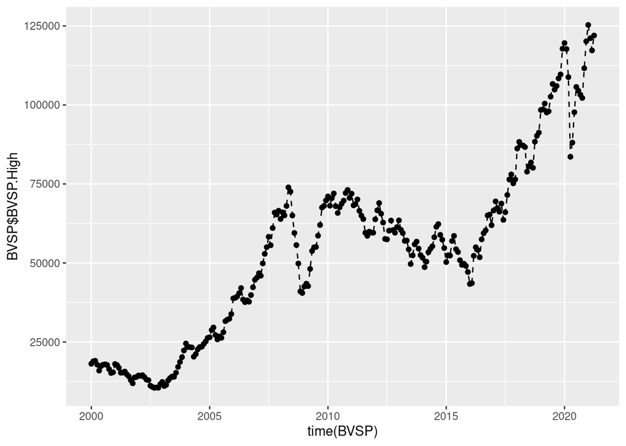

```r
# Variável High
ggplot(BVSP, aes(time(BVSP), BVSP$BVSP.High, group=1)) +
  geom_line(color="black",linetype = "dashed")+
  geom_point()
```

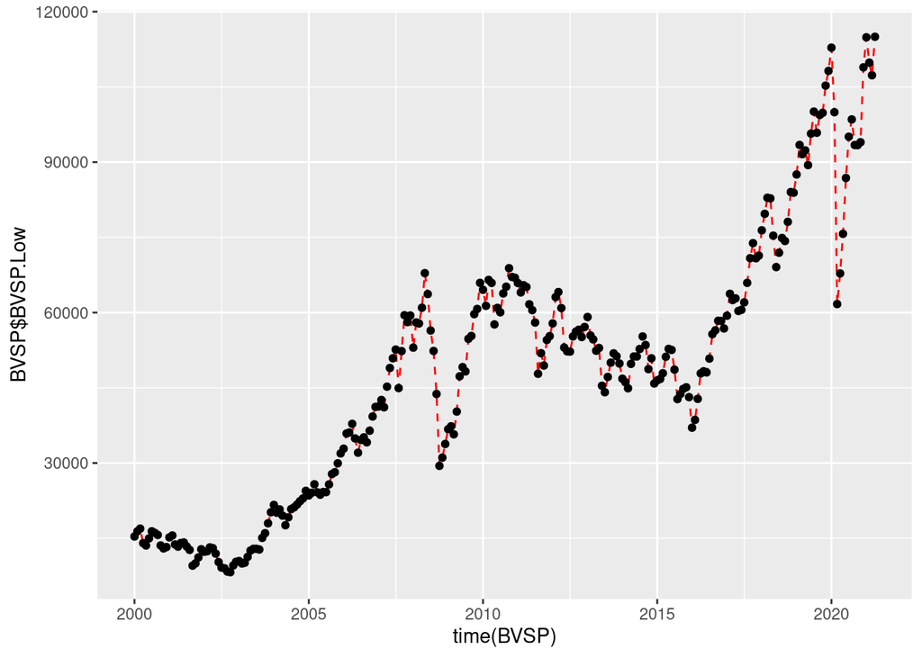

```r
# Variável Low
ggplot(BVSP, aes(time(BVSP), BVSP$BVSP.Low, group=1)) +
  geom_line(color="red",linetype = "dashed")+
  geom_point()
```

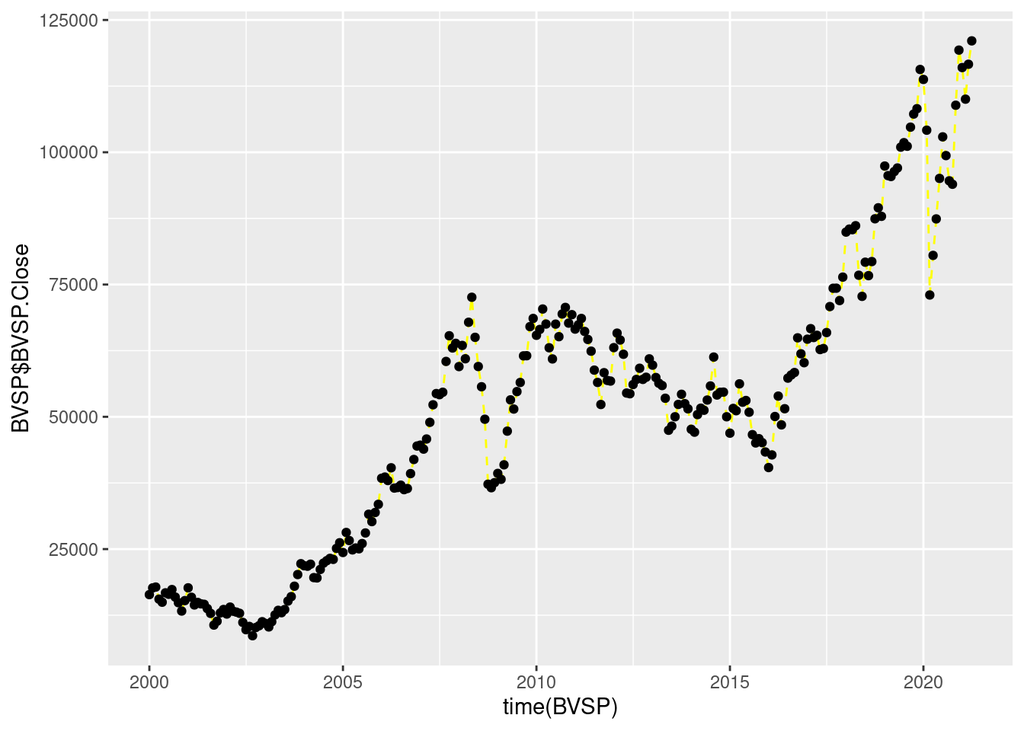

```r
# Variável Closed
ggplot(BVSP, aes(time(BVSP), BVSP$BVSP.Close, group=1)) +
  geom_line(color="yellow",linetype = "dashed")+
  geom_point()
```

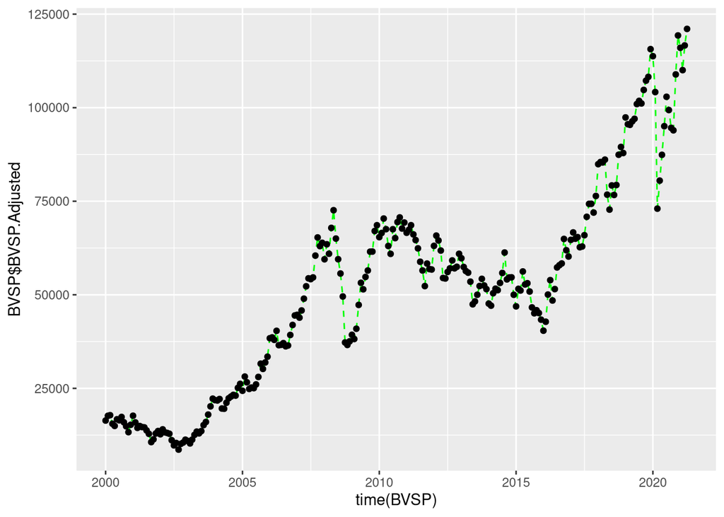

```r
# Variável Adjusted
ggplot(BVSP, aes(time(BVSP), BVSP$BVSP.Adjusted, group=1)) +
  geom_line(color="green",linetype = "dashed")+
  geom_point()
```

### c. Crie um gráfico Q-Q para cada variável de sua base de dados. (use as funções presentes no pacote ggpubr);

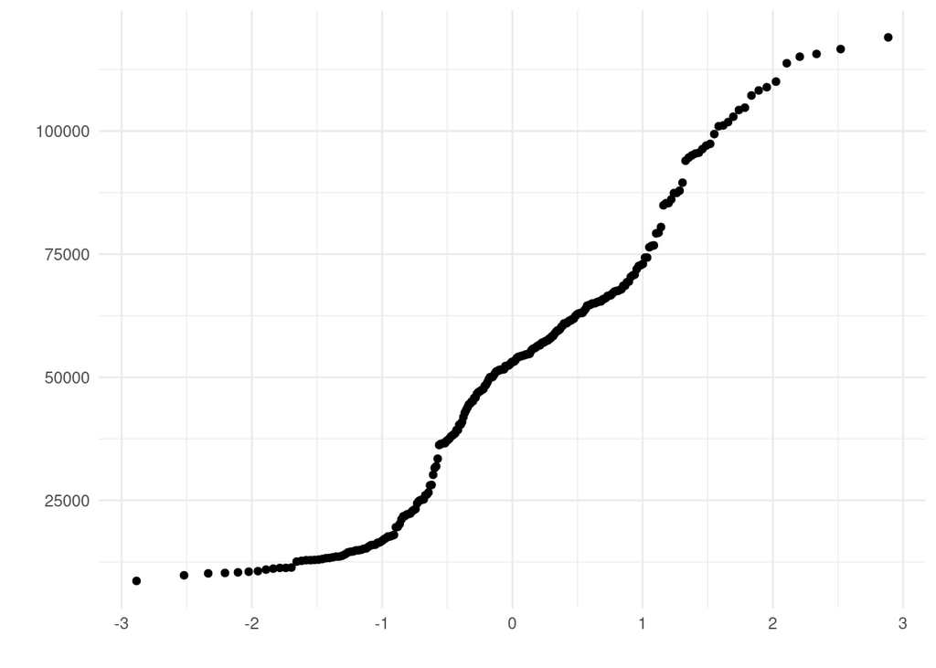

```r
library(ggpubr)
qplot( sample = BVSP.Open , data = BVSP)+ theme_minimal()
```

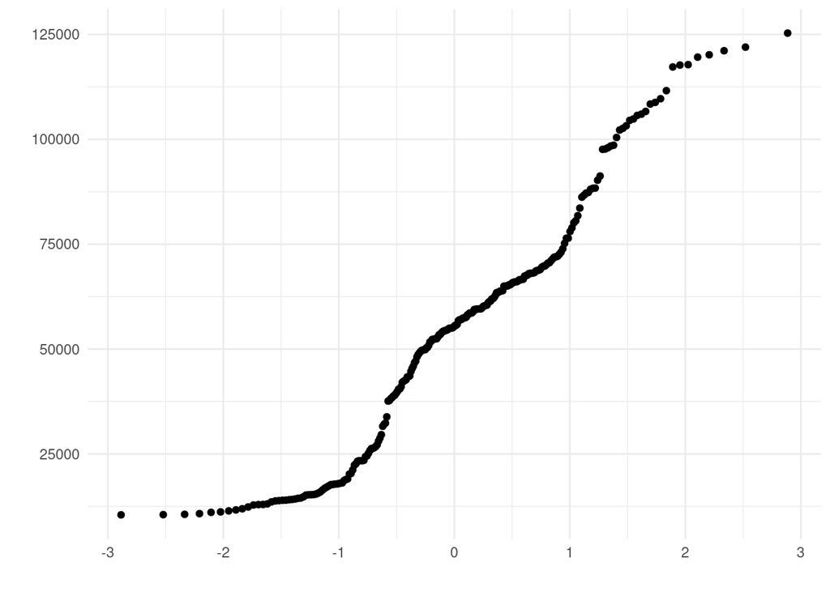

```r
qplot( sample = BVSP.High , data = BVSP)+ theme_minimal()
```

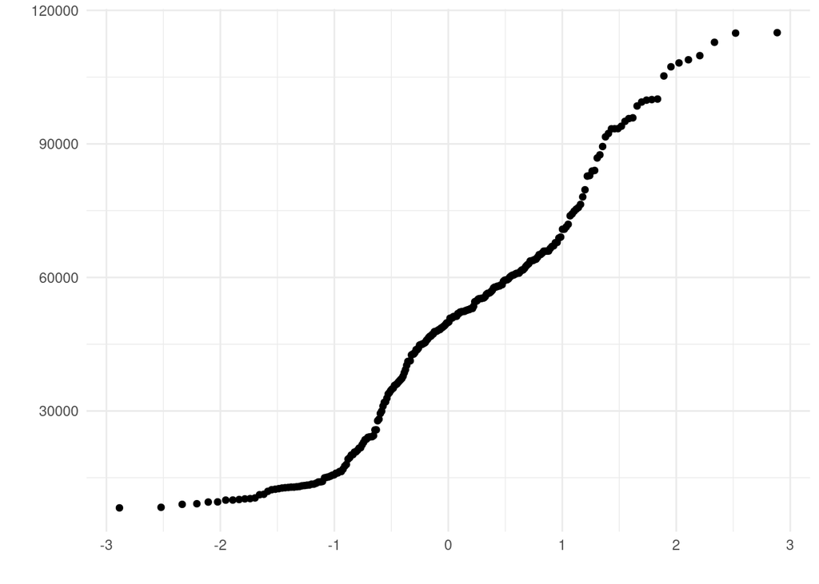

```r
qplot( sample = BVSP.Low , data = BVSP)+ theme_minimal()
```

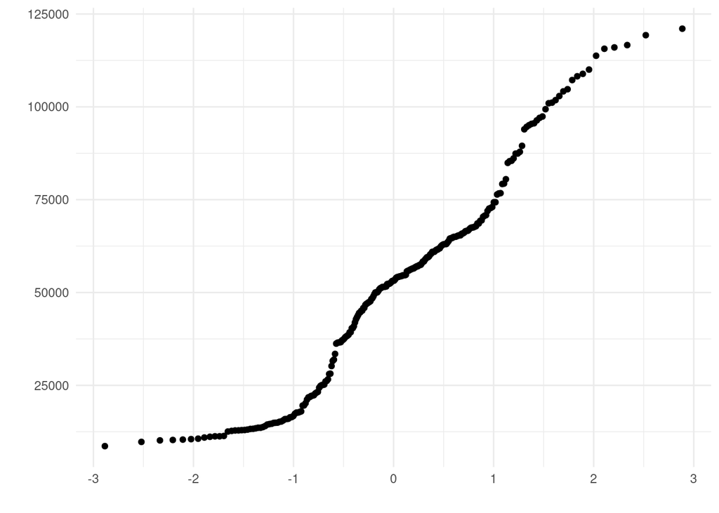

```r
qplot( sample = BVSP.Close , data = BVSP)+ theme_minimal()
```

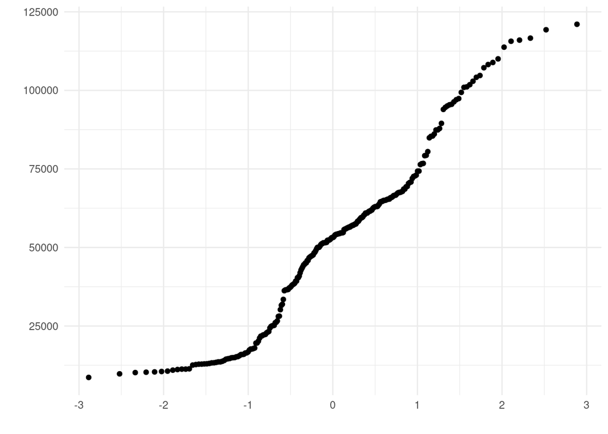

```r
qplot( sample = BVSP.Adjusted , data = BVSP)+ theme_minimal()
```

### d. Execute um teste de normalidade Shapiro-Wilk;

```r
bopen <- BVSP$BVSP.Open
shapiro.test(as.numeric(bopen))
```

```
##
##  Shapiro-Wilk normality test
##
## data:  as.numeric(bopen)
## W = 0.95541, p-value = 4.387e-07
```

```r
bHigh <- BVSP$BVSP.High
shapiro.test(as.numeric(bHigh))
```

```
##
##  Shapiro-Wilk normality test
##
## data:  as.numeric(bHigh)
## W = 0.95323, p-value = 2.469e-07
```

```r
bLow <- BVSP$BVSP.Low
shapiro.test(as.numeric(bLow))
```

```
##
##  Shapiro-Wilk normality test
##
## data:  as.numeric(bLow)
## W = 0.95603, p-value = 5.177e-07
```

```r
bClose <- BVSP$BVSP.Close
shapiro.test(as.numeric(bClose))
```

```
##
##  Shapiro-Wilk normality test
##
## data:  as.numeric(bClose)
## W = 0.95561, p-value = 4.621e-07
```

```r
bAdj <- BVSP$BVSP.Adjusted
shapiro.test(as.numeric(bAdj))
```

```
##
##  Shapiro-Wilk normality test
##
## data:  as.numeric(bAdj)
## W = 0.95561, p-value = 4.621e-07
```

### 6. Qualidade de dados tem sido um dos temas mais abordados nos projetos de estruturação em data analytics, sendo um dos principais indicadores do nível de maturidade das organizações. Um dos problemas mais comuns de qualidade é relacionado à completude de dados. Em suas palavras, como é definido completude? Qual o impacto em uma análise exploratória de dados?

#### a. uma variável da sua base de dados e um gráfico em linha seja mostrado na tela;

#### b. escolher a cor da linha do gráfico;

#### c. selecionar o limite inferior e superior do eixo X do gráfico;

#### d .selecionar o limite inferior e superior do eixo Y do gráfico.

### 10. Disponibilize os códigos (RMarkdown e Shiny) em uma plataforma de compartilhamento de códigos (sugestão GitHub)

#### https://github.com/Wagner85/analise_exploratorio_BVSP

#### https://rpubs.com/wagner85/AnaliseExploratoria_Bovespa